# Kevin Martin CIS700 - Monday @ 8:00pm EST

Assessment 2

# 1. Data Setup

Dataset found here: https://www.kaggle.com/georgezakharov/historical-data-on-the-trading-of-cryptocurrencies/kernels

```python
#python libararies
import pandas as pd
import matplotlib.pyplot as plt
%matplotlib inline
import numpy as np
import seaborn as sns
import warnings
warnings.filterwarnings("ignore")
from numpy import nan
from scipy import stats
from sklearn import decomposition, datasets
from sklearn import tree
from sklearn.pipeline import Pipeline
from sklearn.metrics import roc_auc_score
from sklearn import metrics
from sklearn.preprocessing import StandardScaler
from sklearn.linear_model import LogisticRegression
from sklearn.tree import DecisionTreeClassifier
from sklearn.metrics import confusion_matrix
from sklearn.metrics import accuracy_score
from sklearn.naive_bayes import GaussianNB
from sklearn.neighbors import KNeighborsClassifier
from sklearn.ensemble import GradientBoostingClassifier
from sklearn.ensemble import RandomForestClassifier
from sklearn.model_selection import train_test_split, GridSearchCV

#load my dataset as a pandas dataframe
path = '/home/kebin/Syracuse/Syracuse/CIS700/Assignment1/crypto.csv'
df =  pd.read_csv(path, sep=',')

#clean dataset by dropping unnecessary columns, missing values, and adding a binary 'IsBit' flag
del_col_list = ['site_url', 'github_url', 'platform_name', 'industry_name', 'crypto_type']
df.drop(del_col_list, axis=1, inplace=True)
df.dropna(inplace=True)
df['IsBit'] = np.where(df['ticker']=='BTC',1,0)
print(df.shape)
df.info()
```

```
(410653, 13)
<class 'pandas.core.frame.DataFrame'>
Int64Index: 410653 entries, 0 to 1818104
Data columns (total 13 columns):
 #   Column                       Non-Null Count   Dtype
---  ------                       --------------   -----
 0   trade_date                   410653 non-null  object
 1   volume                       410653 non-null  float64
 2   price_usd                    410653 non-null  float64
 3   price_btc                    410653 non-null  float64
 4   market_cap                   410653 non-null  float64
 5   capitalization_change_1_day  410653 non-null  float64
 6   USD_price_change_1_day       410653 non-null  float64
 7   BTC_price_change_1_day       410653 non-null  float64
 8   crypto_name                  410653 non-null  object
 9   ticker                       410653 non-null  object
 10  max_supply                   410653 non-null  float64
 11  minable                      410653 non-null  float64
 12  IsBit                        410653 non-null  int64
dtypes: float64(9), int64(1), object(3)
memory usage: 43.9+ MB
```

```python
print(df[df.ticker=='BTC'].shape[0])
```

```
1554
```

```python
df['ticker'].value_counts()
```

```
LBTC    1759
DASH    1554
XRP     1554
FTC     1554
LTC     1554
        ...
CELC      11
KDG       11
IBS       10
SCOP       6
HPAY       4
Name: ticker, Length: 637, dtype: int64
```

```python
#Driver function
final_vars = ['volume', 'price_usd', 'market_cap', 'capitalization_change_1_day', 'max_supply', 'minable']
x = df[final_vars]
y = df.IsBit

x_train, x_test, y_train, y_test = train_test_split(x, y, test_size=0.2, random_state=16)
scaler = StandardScaler().fit(x_train)
x_train = scaler.transform(x_train)
x_test = scaler.transform(x_test)

def evaluate(model, graph_flag):
    out_mod = model.fit(x_train, y_train)
    y_pred_mod = model.predict(x_test)
    cm = confusion_matrix(y_test, y_pred_mod)
    print ("Confusion Matrix : \n", cm)
    print ("Accuracy : ", accuracy_score(y_test, y_pred_mod))
    print("Precision:",metrics.precision_score(y_test, y_pred_mod, average='micro'))
    print("Recall:",metrics.recall_score(y_test, y_pred_mod, average='micro'))
    if graph_flag == 1:
        sns.heatmap(cm)
    return out_mod
```

# Question 1

Using two features, I will calcuate variance, entropy, conditional entropy with the target (IsBit) and information gain.

```python
# Variance for volume
import statistics
print('Variance of volume: ', statistics.variance(df.volume))
```

```
Variance of volume:  7.44604755872481e+17
```

```python
# Entropy
Y=df.volume
unique, count = np.unique(Y, return_counts=True, axis=0)
prob = count/len(Y)
en = np.sum((-1)*prob*np.log2(prob))
print('Entropy of variance: ',en)
```

```
Entropy of variance:  15.658394884290015
```

```python
# Conditional entropy of IsBit given Volume

def entropy(Y):

    unique, count = np.unique(Y, return_counts=True, axis=0)
    prob = count/len(Y)
    en = np.sum((-1)*prob*np.log2(prob))
    return en


#Joint Entropy
def jEntropy(Y,X):

    YX = np.c_[Y,X]
    return entropy(YX)

#Conditional Entropy
def cEntropy1(Y, X):
        return jEntropy(Y, X) - entropy(X)

print('ISBit|Volume: ', cEntropy1(df.IsBit,df.volume))
```

```
ISBit|Volume:  2.4351459748217508e-05
```

```python
# Information gain
gain = cEntropy1(df.IsBit,df.volume) - ((df[df.ticker=='BTC'].shape[0]/df.shape[0]) * jEntropy(df.IsBit,df.volume) + (df[df.volume>=0].shape[0])/df.shape[0] * jEntropy(df.volume,df.IsBit))
print(gain)
```

```
-15.717649738126113
```

# Question 1b

Clusters from dataset, using K Means clustering. First, cluster of 5 and the "full" agorithm.

Next, a cluster of 3, with the max iterations doubled (stock is 100), and a different choice in algorithm (the full is an older format, Elkan is better suited to more well-defined data).

```python
from sklearn.cluster import KMeans
kmeans = KMeans(n_clusters=5, algorithm="full")
kmeans_train = evaluate(kmeans, 0)
```

```
Confusion Matrix :
 [[49327     1 32110   368]
 [  156   169     0     0]
 [    0     0     0     0]
 [    0     0     0     0]]
Accuracy :  0.6026469907830174
Precision: 0.6026469907830174
Recall: 0.6026469907830174
```

```python
kmeans2 = KMeans(n_clusters=3, max_iter=200, algorithm="elkan")
kmeans_train2 = evaluate(kmeans2, 0)
```

```
Confusion Matrix :
 [[32478     1 49327]
 [    0   169   156]
 [    0     0     0]]
Accuracy :  0.3974991172638833
Precision: 0.3974991172638833
Recall: 0.3974991172638833
```

# Question 2a

First, three different distance measures between two features (volume as the independent and the IsBit flag as the dependent) using euclidean distance, Manhattan (city block) distance, and Minkowski distance.

Next, K-Nearest Neighbors will be shown but using a different distance measure each time. Note that I will be keeping the n_neighbors the same, but changing p and the metric to match.

```python
from scipy.spatial import distance
euc_dist = distance.euclidean(df.volume, df.IsBit)
print('Euclidean: ', euclidean_distance)
man_dist = distance.cityblock(df.volume, df.IsBit)
print('Manhattan: ', man_dist)
mink_dist = distance.minkowski(df.volume, df.IsBit)
print('Minkowski: ', mink_dist)
```

[output not shown]

Note that Euclidean and Minkowski return the exact same result. When "p" is not changed, Minkowski will be equal to Euclidean.

```python
euc = KNeighborsClassifier(n_neighbors = 6, p = 1, metric='euclidean')
euc_train = evaluate(euc, 1)
```

```
Confusion Matrix :
 [[81796    10]
 [    8   317]]
Accuracy :  0.999780837929649
Precision: 0.9694189602446484
Recall: 0.9753846153846154
```

```python
man = KNeighborsClassifier(n_neighbors = 6, p = 2, metric='cityblock')
man_train = evaluate(man, 1)
```

```
Confusion Matrix :
 [[81798     8]
 [    9   316]]
Accuracy :  0.999793013600224
Precision: 0.9753086419753086
Recall: 0.9723076923076923
```

```python
mink = KNeighborsClassifier(n_neighbors = 6, p = 3, metric='minkowski')
mink_train = evaluate(mink, 1)
```

```
Confusion Matrix :
 [[81796    10]
 [   10   315]]
Accuracy :  0.9997564865884989
Precision: 0.9692307692307692
Recall: 0.9692307692307692
```

Because the IsBit flag is easy to calculate, all three distance measures did exteremly well. However, we can see that Manhattan distance slightly outperformed the other two. Because of the binary nature of the IsBit flag, the Manhattan distance metric is better suited to the situation.

# Question 2b

To demonstrate the paradigm of underfitting vs. overfitting, I will continue to use the KNN algorithm. Here, increasing K will reduce overfitting. So, in the two extreme examples:

K=1: complete overfitting K=n: complete underfitting

Thus the need to strike a balance is key when using this approach.

See below two examples, one where k is equal to 1 for overfitting, and one where k is equal to 1000 for underfitting.

```python
#overfitting KNN in the extreme case where k=1
man_over = KNeighborsClassifier(n_neighbors = 1, p = 2, metric='cityblock')
man_train = evaluate(man_over, 1)
```

```
Confusion Matrix :
 [[81797     9]
 [    7   318]]
Accuracy :  0.9998051892707991
Precision: 0.9724770642201835
Recall: 0.9784615384615385
```

```
Confusion Matrix :
 [[81806     0]
 [  157   168]]
Accuracy :  0.9980884197197161
Precision: 1.0
Recall: 0.5169230769230769
```

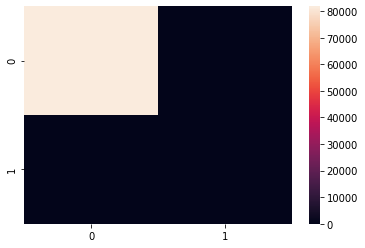

```python
#underfitting KNN in the extreme case where k=1000
man_under = KNeighborsClassifier(n_neighbors = 1000, p = 2, metric='cityblock')
man_train = evaluate(man_under, 1)
```

As expected, the metrics did not change much with overfitting (again, IsBit is relatively easy for the algorithm to identify), but observe how poorly the recall behaved when k was set to 1000. Here we see an excellent example of a model that has very much been underfit.

# Question 5a

```python
# Loan Status prediction:

total = 16
college = 5/8
gender = 1/8
status = 8/12
print('The liklihood that  a loan is in colllection given a female in college is: ',college*gender/status)
```

```
The liklihood that  a loan is in colllection given a female in college is:  0.1171875
```

```python
from math import log2
def entropy(class0, class1):
    return -(class0 * log2(class0) + class1 * log2(class1))
ent1 = entropy(college,status)
print('The entropy of loan status given college: ',ent1)
```

```
The entropy of loan status given college:  0.8137699411761694
```

```python
ent2 = entropy(gender,status)
print('The entropy of loan status given gender: ',ent2)
```

```
The entropy of loan status given gender:  0.7649750004807708
```

```python
print('Joint entropy: ',entropy(ent1, ent2))
```

```
Joint entropy:  0.5376142741235013
```

```python
# Information gain
gain = cEntropy1(ent1,ent2) - ((college/total) * jEntropy(ent1,ent2) + (gender/total) * jEntropy(ent2,ent1))
print(gain)
```

[output not shown]